# Primer parcial - Dasometría

Cristian Gañan (1059710617) - Sofia Muñoz Duque (1020490502)

25 de noviembre de 2019

### Punto 1

*Analice la distribución de los DAP (cm) y área basal (cm2) de los árboles muestreados en cada finca mediante el uso de un histograma en cada una de ellas. Concluya y explique que diferencias estructurales generales se visualizan entre fincas, para cada una de las variables estudiadas. Analice los histogramas usando intervalos de clase de 5 cm (para el DAP) y usando el número de intervalos de clase que se defina bajo la regla de Sturges para el área basal.*

```r
data<- read_xlsx("parcial1.xlsx")

data<- data %>% select(Parcela,
                       Finca, ...4) %>%
  rename(DAP_cm= Parcela,
         Parcela= Finca,
         Finca= ...4) %>%
  mutate(Parcela = as.factor(Parcela),
         Finca= as.factor(Finca))

data %>% group_by(Finca, Parcela) %>% summarise(cu1= length(Finca))
```

| Finca | Parcela | cu1 |
| --- | --- | --- |
| finca0 | p_1 | 28 |
| finca0 | p_10 | 33 |
| finca0 | p_2 | 20 |
| finca0 | p_3 | 32 |
| finca0 | p_4 | 36 |
| finca0 | p_5 | 30 |
| finca0 | p_6 | 26 |
| finca0 | p_7 | 28 |
| finca0 | p_8 | 27 |
| finca0 | p_9 | 30 |
| finca1 | p_1 | 10 |
| finca1 | p_10 | 9 |
| finca1 | p_11 | 12 |
| finca1 | p_12 | 7 |
| finca1 | p_13 | 11 |
| finca1 | p_14 | 17 |
| finca1 | p_15 | 11 |
| finca1 | p_16 | 14 |
| finca1 | p_17 | 4 |
| finca1 | p_18 | 8 |
| finca1 | p_19 | 14 |
| finca1 | p_2 | 8 |
| finca1 | p_20 | 5 |
| finca1 | p_21 | 10 |
| finca1 | p_22 | 10 |
| finca1 | p_23 | 5 |
| finca1 | p_24 | 13 |
| finca1 | p_25 | 11 |
| finca1 | p_26 | 6 |
| finca1 | p_27 | 13 |

[output cut: 143 more lines]

##### Distribuciones diametricas para DAP

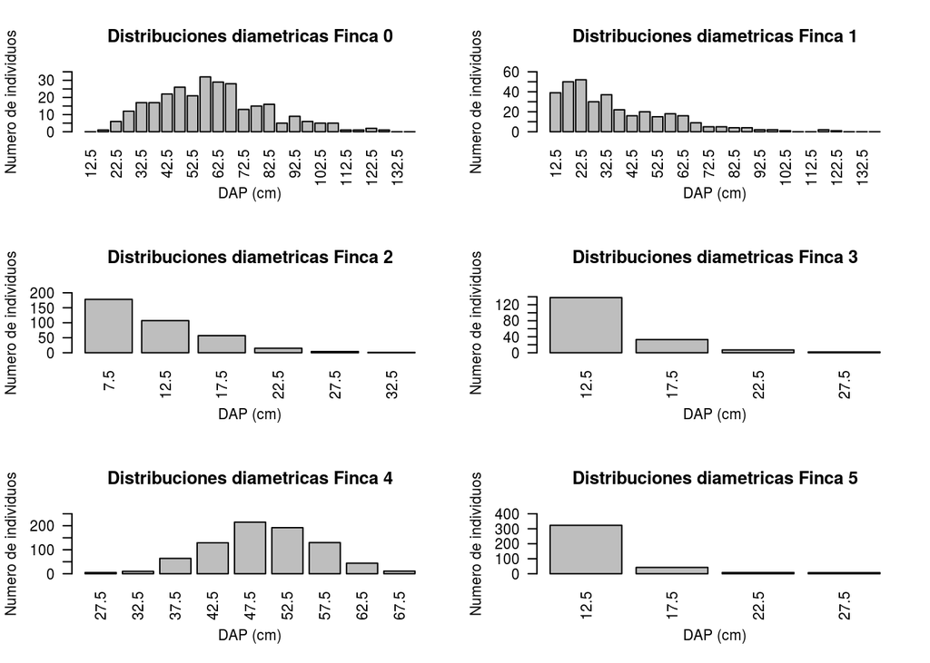

**Fig.1** Distribuciones diametricas para DAP

```r
par(mfrow=c(3,2))
barplot(hist_f0$counts,las=2, xlab= "DAP (cm)", ylab="Numero de individuos",ylim=c(0,35),
        main="Distribuciones diametricas Finca 0")
barplot(hist_f1$counts,las=2, xlab= "DAP (cm)", ylab="Numero de individuos",ylim=c(0,60),
        main="Distribuciones diametricas Finca 1")
barplot(hist_f2$counts,las=2, xlab= "DAP (cm)", ylab="Numero de individuos",ylim=c(0,200),
        main="Distribuciones diametricas Finca 2")
barplot(hist_f3$counts,las=2, xlab= "DAP (cm)", ylab="Numero de individuos",ylim=c(0,150),
        main="Distribuciones diametricas Finca 3")
barplot(hist_f4$counts,las=2, xlab= "DAP (cm)", ylab="Numero de individuos",ylim=c(0,250),
        main="Distribuciones diametricas Finca 4")
barplot(hist_f5$counts,las=2, xlab= "DAP (cm)", ylab="Numero de individuos",ylim=c(0,400),
        main="Distribuciones diametricas Finca 5")
```